# My Simple Logistic Regression

## Background

$$H_0: \text{A logistical regression model will be a good fit or test to run for the data}$$
$$H_a: \text{A logistical regression model will not be a good fit}$$

## Analysis

To decide whether the budget amount I shared will hopefully cover my utilities will be determined by the following equation. This equation provides me the probability whether the determined amount, `$20` for electric or `$30` for gas, will pay the bill based off of the temperature outside.

$$P(Y_i = 1|x_i) = \frac{e^{\beta_0+\beta_1 x_i}}{1+e^{\beta_0 + \beta_1 x_i}} = \pi_i$$
where you see an observation $i$, it will mean:

- $Y_i = 1$ denotes that `$20` or `$30` will cover the respective utility.
- $Y_i = 0$ denotes that the data is above the desired budget amount, and
- $x_i$ denotes the average outside temperature in degrees farenheit for the month.

Note that if $\beta_1$ is zero in the above model, then $x_i$ (temperature) provides no insight whether my utilities will be covered. Thus, we could test the hypothesis that

$$H_0: \beta_1 = 0 \\
H_a: \beta_1 \neq 0$$

### Electric Bills

#### Is this test worth pursuing?

```r
My.electric.bills.glm <- glm(ElectricBill <= 20 ~ Average.Temperature, data = Mybills,
 family=binomial)
pander(hoslem.test(My.electric.bills.glm$y, My.electric.bills.glm$fitted))
```

Hosmer and Lemeshow goodness of fit (GOF) test: `My.electric.bills.glm$y, My.electric.bills.glm$fitted`

| Test statistic | df | P value |
| --- | --- | --- |
| 12.03 | 8 | 0.1499 |

Usually a Hosmer-Lemeshow Goodness of Fit Test is ran after conducting a logistical regression test first because the required numbers needed to complete the formula for a Goodness of Fit test come from the logistical test. We will analyze that logistical test later, yet I would like to first answer the first hypothesis that running a logistical regression test on the electric bill data is a good fit and to thus continue forward. The Goodness of Fit’s p-value is `0.1499` meaning that we fail to reject the null hypothesis because our $\sigma$ = .05.

#### General Information

Now that we have determined this is the right type of test to run, let’s see if the results from the actual logistical test show that I can base my budget off of the temperature. We will do so by obtaining the values of $\beta_0$ and $\beta_1$ and looking at $\beta_1$’s p-value.

```r
My.electric.bills.glm <- glm(ElectricBill <= 20 ~ Average.Temperature, data = Mybills,
 family=binomial)
pander(summary(My.electric.bills.glm))
```

|  | Estimate | Std. Error | z value | Pr(>\|z\|) |
| --- | --- | --- | --- | --- |
| **(Intercept)** | -1.492 | 1.941 | -0.7685 | 0.4422 |
| **Average.Temperature** | 0.04684 | 0.04323 | 1.084 | 0.2786 |

(Dispersion parameter for binomial family taken to be 1 )

| Null deviance: | 14.42 on 10 degrees of freedom |
| --- | --- |
| Residual deviance: | 13.10 on 9 degrees of freedom |

```r
#Can I use the pander function with this type of summary?
#Yes, it is. - Vivian
```

Here we see that the estimate of probability or $\pi_i$ is:

$$P(Y_i = 1|x_i) = \frac{e^{-1.492 + 0.0468 x_i}}{1+e^{-1.492 + 0.0468 x_i}} = \pi_i$$

#### A Look At The Data

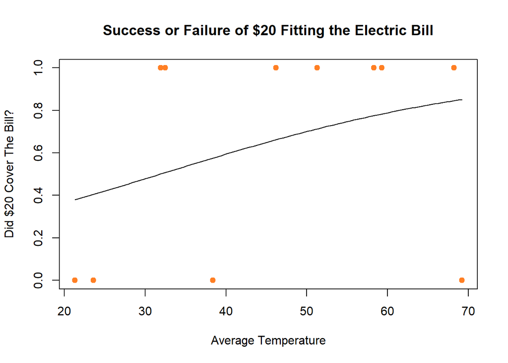

```r
plot(ElectricBill <= 20 ~ Average.Temperature, data=Mybills, xlab="Average Temperature", ylab="Did $20 Cover The Bill?", main="Success or Failure of $20 Fitting the Electric Bill", col="chocolate1", pch=19)
curve(exp(-1.492 + 0.04684*x)/(1 + exp(-1.492 + 0.04684*x)), add = TRUE)
```

When I first looked at this chart, I thought that it looked okay. But then I realized this was for the electricity bill and that average temperatures of both 20° F and 70° F were failing to have `$20` cover the bill. That didn’t make sense to me. So after taking another look at the data I realized a key part in the data. My wife did not have a job when we initially moved here to Rexburg. It was not until May that she found work. From May to September, she worked part-time until mid-September when she was offered full-time employment in her position. After realizing this, the graph makes sense why the budget was not covering two vastly different average temperatures.  
Additionally, I noticed that there were two months with aproxametiately the same average temperature, 70° F, and yet the budget covered the bill one month and not another. Here I realized that the month in which the budget covered the bill, August’s, was during the three weeks my wife and I had left to visit India.  
In short, this data is a bit abnormal due to the fact that my wife was home all day during the winter months to use the electricity. More information will need to be collected to have a better use of this data.

### Gas Bills

#### Is this test worth pursuing?

```r
My.gas.bills.glm <- glm(GasBill <= 30 ~ Average.Temperature, data = Mybills,
 family=binomial)
pander(hoslem.test(My.gas.bills.glm$y, My.gas.bills.glm$fitted))
```

Hosmer and Lemeshow goodness of fit (GOF) test: `My.gas.bills.glm$y, My.gas.bills.glm$fitted`

| Test statistic | df | P value |
| --- | --- | --- |
| 2.401 | 8 | 0.9662 |

Usually a Hosmer-Lemeshow Goodness of Fit Test is ran after conducting a logistical regression test first because the required numbers needed to complete the formula for a Goodness of Fit test come from the logistical test. We will analyze that logistical test later, yet I would like to first answer the first hypothesis that running a logistical regression test on the gas bill data is a good fit and to thus continue forward. The Goodness of Fit’s p-value is `0.9662` meaning that we fail to reject the null hypothesis.

#### General Information

Now that we have determined this is the right type of test to run, let’s see if the results from the actual logistical test show that I can base my budget off of the temperature. We will do so by obtaining the values of $\beta_0$ and $\beta_1$ and looking at $\beta_1$’s p-value.

```r
My.gas.bills.glm <- glm(GasBill <= 30 ~ Average.Temperature, data = Mybills,
 family=binomial)
pander(summary(My.gas.bills.glm), fig.align="center")
```

|  | Estimate | Std. Error | z value | Pr(>\|z\|) |
| --- | --- | --- | --- | --- |
| **(Intercept)** | -17.38 | 20.91 | -0.8313 | 0.4058 |
| **Average.Temperature** | 0.5411 | 0.6448 | 0.8391 | 0.4014 |

(Dispersion parameter for binomial family taken to be 1 )

| Null deviance: | 12.891 on 10 degrees of freedom |
| --- | --- |
| Residual deviance: | 3.204 on 9 degrees of freedom |

Here we see that the estimate of probability or $\pi_i$ is:

$$P(Y_i = 1|x_i) = \frac{e^{-17.38 + 0.5411 x_i}}{1+e^{-17.38 + 0.5411 x_i}} = \pi_i$$

#### A Look At The Data

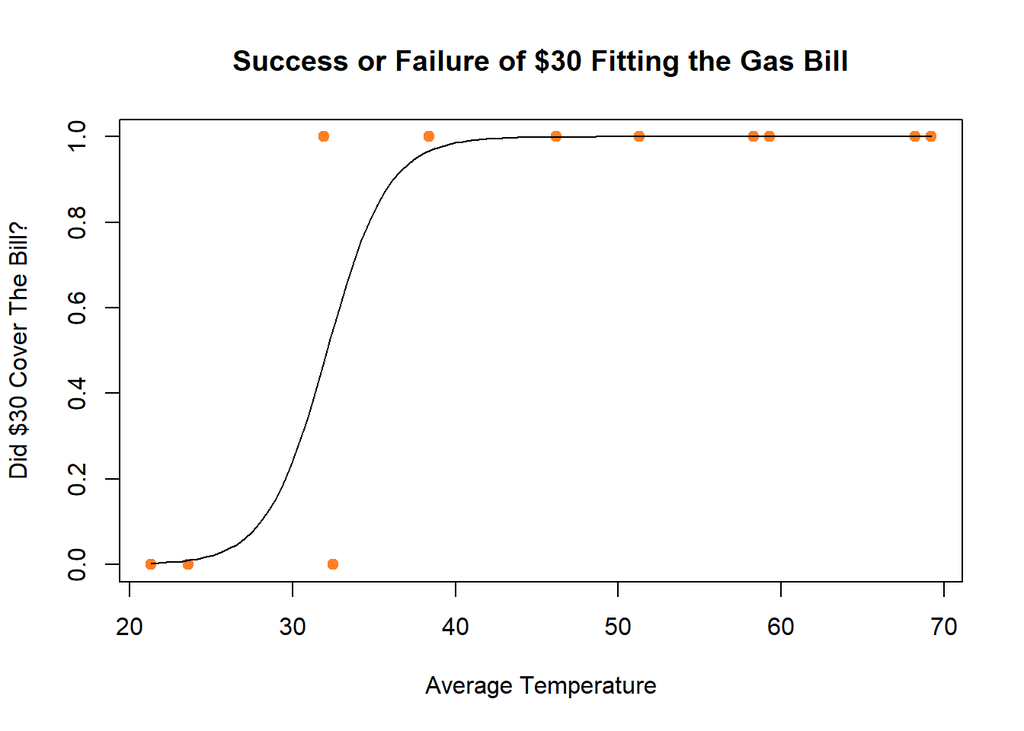

```r
plot(GasBill <= 30 ~ Average.Temperature, data = Mybills, xlab="Average Temperature", ylab="Did $30 Cover The Bill?", main="Success or Failure of $30 Fitting the Gas Bill", col="chocolate1", pch=19)
curve(exp(-17.38 + 0.5411*x)/(1 + exp(-17.38 + 0.5411*x)), add = TRUE)
```

```r
#ggplot(Mybills, aes(x=Average.Temperature, y=GasBill <= 30)) +
#  geom_point(color = "ivory3", pch = 18) +
#  labs(title="Success or Failure of $20 Fitting the Gas Bill", x="Average #Temperature", y="Did $20 Cover The Bill?") +
#  theme_bw() +
#  stat_function(fun=exp(-17.38 + 0.5411*x)/(1 + exp(-17.38 + 0.5411*x)))
```

When reviewing the graph for this logistical model, I did not see anything out of the ordinary.

### Show Data

The data comes from my personal account with Rocky Mountain Power and Intermountian Gas. It starts from when we moved into our trailer in January 2019.

#### Original Data

```r
datatable(Mybills)
```

[output not shown]

[output cut: 1 more lines]

## Conclusion

The ability to trust the effectiveness of this data is very low due to our measurements with the $p$-values, but for fun let’s look into this a little bit more if we were to trust the results. Although reaching 0° F is possible here in Rexburg, Idaho, the likelihood of Rexburg reaching an average temperature of 0° F is unlikely and so we will not be able to interpet the value of $e^{b_0}$. Yet, we will be able to show that electric’s $e^{b_1}$ = $e^{0.04684}$ $\approx$ `1.05` and gas’s $e^{b_1}$ = $e^{0.5411}$ $\approx$ `1.72`. This means that for every 1° F increase we can say that the odds of our budget covering the bill will increase by a factor of `1.05` or 5% for electricity and `1.72` or 72% for gas. So let’s look at that.

| Temperature | Electricity’s Probability | Gas’s Probability |
| --- | --- | --- |
| 10° F | 0.264 | 10^{-5} |
| 20° F | 0.365 | 0.0014 |
| 30° F | 0.478 | 0.2406 |
| 40° F | 0.594 | 0.9861 |
| 50° F | 0.701 | 0.9999 |
| 60° F | 0.789 | 1 |
| 70° F | 0.857 | 1 |
| 80° F | 0.905 | 1 |
| 90° F | 0.938 | 1 |